# Covid-19 Data Analysis of India

Pankaj & Sakshi

12/01/2021

#### This data is taken from Bing COVID-19 Tracker (www.bing.com/covid). Bing COVID-19 data includes confirmed, fatal, and recovered cases from all regions. The data is collected from multiple trusted, reliable sources, including the World Health Organization (WHO), Centers for Disease Control and Prevention (CDC), national and state public health departments, BNO News, 24/7 Wall St., and Wikipedia.

##### Importing Data and packages

```r
# add packages you need for this assignment
library("xlsx")
library(tidyverse)  # includes tibbles, ggplot2, dyplr, and more.
```

```r
Demo2<- read.csv("~/Desktop/Demo2.csv")
ind<- read.csv("~/Desktop/ind.csv")
totaldata <- read.xlsx("~/Downloads/Indiaset.xlsx", 1, header=TRUE)
```

```r
str(Demo2) #Structure of dataset
```

```
## 'data.frame':    642 obs. of  17 variables:
##  $ ID                : int  131295993 138635126 69421786 138635138 138635121 131295998 131295999 131296003 49177030 39015861 ...
##  $ Date              : chr  "4/30/21" "5/31/21" "9/30/20" "5/31/21" ...
##  $ Confirmed         : int  4665754 5761015 1400922 2123029 2618735 1174552 1282504 744602 431719 180298 ...
##  $ Confirmed.Change  : int  63282 14123 16476 26513 14304 25219 30180 15902 9601 5537 ...
##  $ Deaths            : int  68813 95344 36662 24232 29090 16147 12570 8581 14994 7855 ...
##  $ Deaths.Changed    : int  828 500 481 478 411 375 332 269 265 245 ...
##  $ Recovered         : int  3868976 5395370 1088322 1770503 2261590 1033825 928971 601161 256158 90911 ...
##  $ Revovered.Change  : int  69710 33000 19163 31223 44473 25288 32494 13677 7543 1951 ...
##  $ Population.Density: int  950 950 950 1440 830 29260 2140 490 950 950 ...
##  $ Admin.Region.1    : chr  "Maharashtra" "Maharashtra" "Maharashtra" "Tamil Nadu" ...
##  $ Month             : chr  "Apr-21" "May-21" "Sep-20" "May-21" ...
##  $ Lattitude         : num  19.5 19.5 19.5 11 14.7 ...
##  $ Longitude         : num  76.1 76.1 76.1 78.4 76.2 ...
##  $ ISO2              : chr  "IN" "IN" "IN" "IN" ...
##  $ ISO3              : chr  "IND" "IND" "IND" "IND" ...
##  $ Country.Region    : chr  "India" "India" "India" "India" ...
##  $ Admin.Region.2    : logi  NA NA NA NA NA NA ...
```

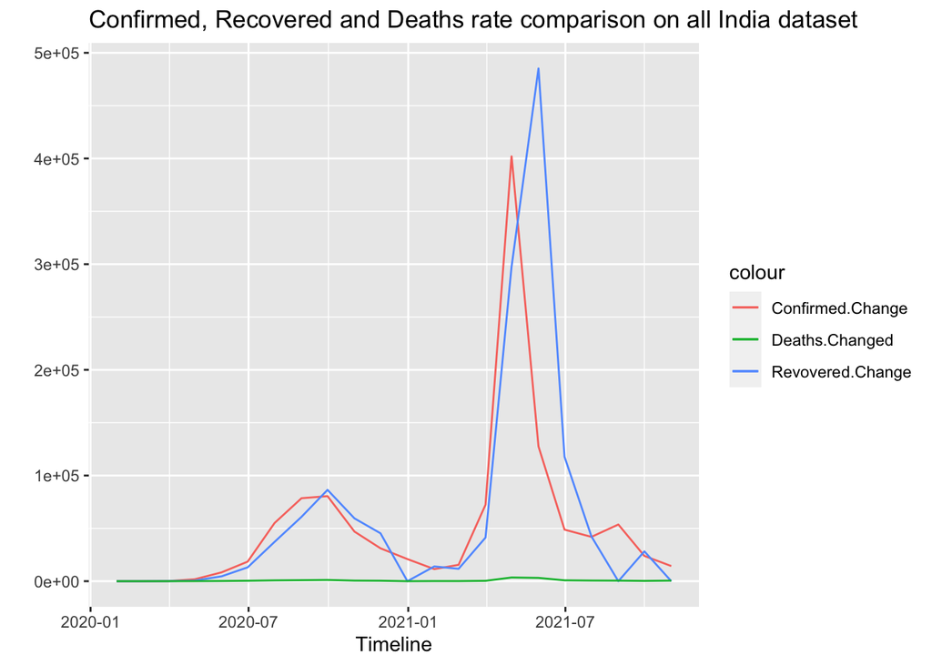

```r
plot1 <-
  ggplot(totaldata, aes(x=Date)) +
  geom_line(aes(y = Confirmed.Change, color = "Confirmed.Change")) +
  geom_line(aes(y = Revovered.Change, color="Revovered.Change")) +
  geom_line(aes(y = Deaths.Changed, color="Deaths.Changed"))

print(plot1 +ggtitle("Confirmed, Recovered and Deaths rate comparison on all India dataset")+ labs(y=" ", x = "Timeline"))
```

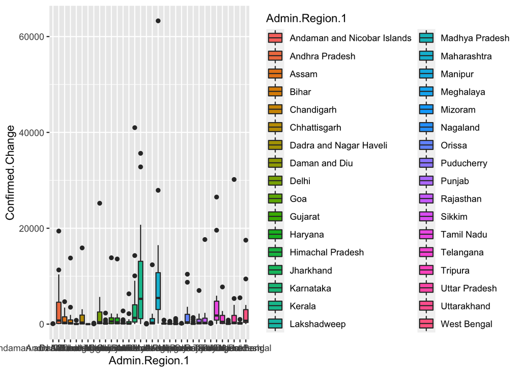

```r
ggplot(data = Demo2, mapping = aes(x = Admin.Region.1, y = Confirmed.Change)) +
  geom_boxplot(aes(fill = Admin.Region.1))
```

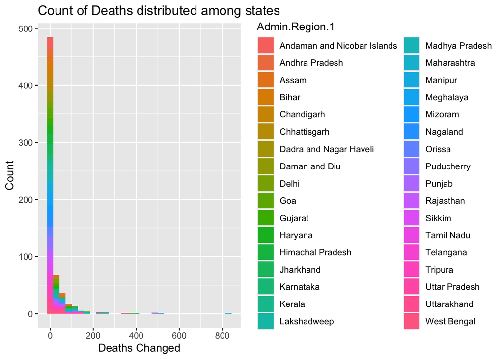

```r
plot2 <- ggplot(data = Demo2, aes(x = Deaths.Changed)) +
  geom_histogram(aes(fill = Admin.Region.1),bins = 30)
print(plot2 +ggtitle("Count of Deaths distributed among states")+ labs(y="Count", x = "Deaths Changed"))
```

[figure not shown]

```r
plot3 <- ggplot(data = Demo2, mapping = aes(x = Confirmed.Change)) +
  geom_line(aes(y = Revovered.Change, color = Admin.Region.1))
print(plot3 +ggtitle("CONFIRMED Vs RECOVERED")+ labs(y="Confirmed Cases", x = "Recovered"))
```

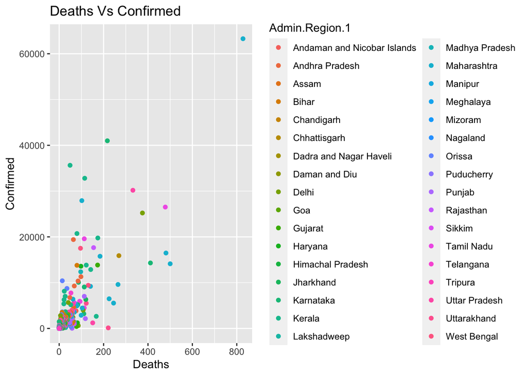

```r
plot4 <-  ggplot(data = Demo2) +
  geom_point(mapping = aes(x = Deaths.Changed, y = Confirmed.Change,colour = Admin.Region.1))
print(plot4 +ggtitle("Deaths Vs Confirmed")+ labs(y="Confirmed", x = "Deaths"))
```

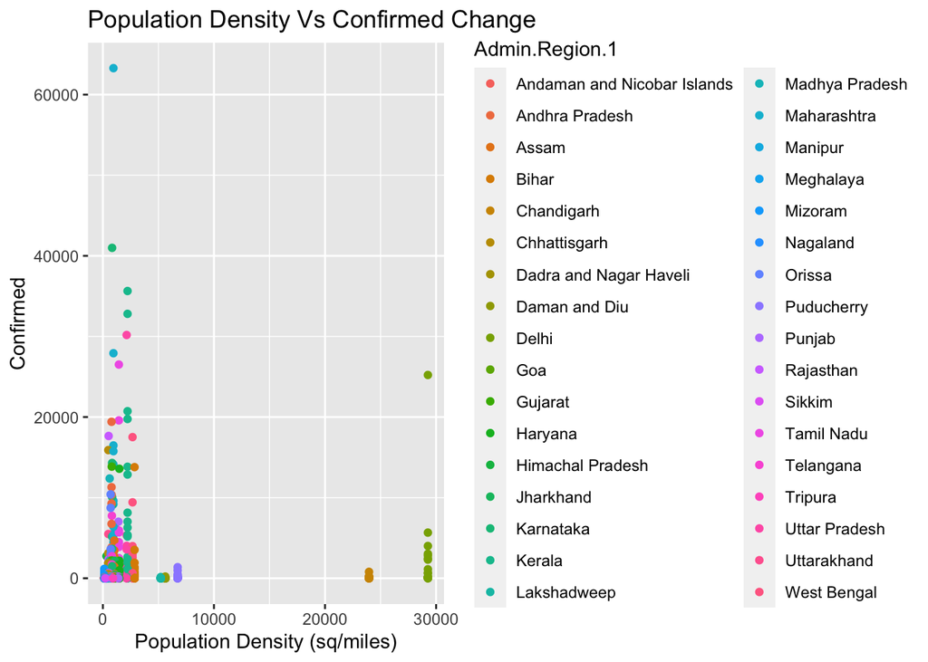

```r
plot5 <-ggplot(data = Demo2) +
  geom_point(mapping = aes(x = Population.Density, y = Confirmed.Change,color = Admin.Region.1))
print(plot5 +ggtitle("Population Density Vs Confirmed Change")+ labs(y="Confirmed", x = "Population Density (sq/miles)"))
```

##### Hypothesis Testing -

- This Hypothesis testing is done on statement that the average number of Confirmed changed cases in the duration of January 2020 - October 2020 is same as Confirmed Changed cases in January 2021 - October 2021.
- null hypothesis, denoted by $H_0$
- alternative hypothesis, denoted by $H_1$
- Assuming variance is equal.

$$\begin{align*}
H_0: \mu_w1=\mu_w2,\\
H_1: \mu_w1 \ne \mu_w2
\end{align*}$$

```r
wave1 <- ind[1:10,]  #Data from Jan 2020 to Oct 2020
wave2 <- ind[13:22,] #Data from Jan 2021 to Oct 2021
```

```r
w1 <- wave1$Confirmed.Change
w2 <- wave2$Confirmed.Change
t.test(w1,w2, var.equal = TRUE, conf.level = .95)
```

```
##
##  Two Sample t-test
##
## data:  w1 and w2
## t = -1.3449, df = 18, p-value = 0.1954
## alternative hypothesis: true difference in means is not equal to 0
## 95 percent confidence interval:
##  -133610.35   29314.15
## sample estimates:
## mean of x mean of y
##   28989.6   81137.7
```

> In the above test we used t-test to compare mean of two sample sets with 95% confidence Interval and the resulted P-value is 0.1954 which is comparitively very large to Alpha (0.05). Since the P-value is larger than alpha we will accept the $H_0$ which stated that both means are equal.

### Regression

```r
library(ISLR)
data(Demo2)
```

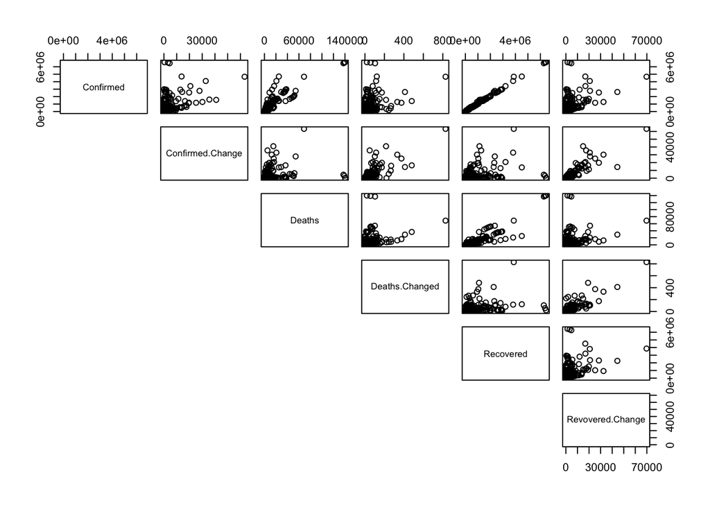

```r
i <- sample(2, nrow(Demo2), replace=TRUE, prob=c(0.8, 0.2))
Demo2Training <- Demo2[i==1,]
Demo2Test <- Demo2[i==2,]
pairs(Demo2Training[,3:8],lower.panel = NULL)
```

> From the above scatterplot matrix we can determine that “Recovered” has direct relationship with “Confirmed cases” and “Deaths”.

```r
library(MASS)
# Create a null model
intercept_only <- lm(Confirmed ~ 1, data=Demo2Training[,3:8])
# Create a full model
all <- lm(Confirmed~., data=Demo2Training[,3:8])
# perform forward step-wise regression
forward <- stepAIC (intercept_only, direction='forward',scope = formula(all))
```

```
## Start:  AIC=13888.41
## Confirmed ~ 1
##
##                    Df  Sum of Sq        RSS   AIC
## + Recovered         1 3.3953e+14 1.3852e+12 11082
## + Deaths            1 2.7437e+14 6.6553e+13 13057
## + Revovered.Change  1 8.1274e+13 2.5964e+14 13752
## + Confirmed.Change  1 6.9591e+13 2.7133e+14 13774
## + Deaths.Changed    1 5.9882e+13 2.8104e+14 13792
## <none>                           3.4092e+14 13888
##
## Step:  AIC=11082.44
## Confirmed ~ Recovered
##
##                    Df  Sum of Sq        RSS     AIC
## + Confirmed.Change  1 1.2246e+12 1.6061e+11  9985.6
## + Revovered.Change  1 1.1068e+12 2.7839e+11 10266.1
## + Deaths.Changed    1 9.4063e+11 4.4453e+11 10504.8
## <none>                           1.3852e+12 11082.4
## + Deaths            1 1.3552e+09 1.3838e+12 11083.9
##
## Step:  AIC=9985.6
## Confirmed ~ Recovered + Confirmed.Change
##
##                    Df  Sum of Sq        RSS    AIC
## + Deaths            1 4.8868e+10 1.1174e+11 9802.6
## + Deaths.Changed    1 4.0505e+10 1.2011e+11 9839.4
## + Revovered.Change  1 3.1918e+10 1.2869e+11 9874.6
## <none>                           1.6061e+11 9985.6
##
## Step:  AIC=9802.58
## Confirmed ~ Recovered + Confirmed.Change + Deaths
##
##                    Df  Sum of Sq        RSS    AIC
## + Revovered.Change  1 3.6149e+10 7.5593e+10 9605.3
## + Deaths.Changed    1 2.1189e+10 9.0554e+10 9697.3
## <none>                           1.1174e+11 9802.6
##
## Step:  AIC=9605.25
## Confirmed ~ Recovered + Confirmed.Change + Deaths + Revovered.Change
##
##                  Df Sum of Sq        RSS    AIC
## + Deaths.Changed  1 940937252 7.4652e+10 9600.9
## <none>                        7.5593e+10 9605.3
##
## Step:  AIC=9600.87
## Confirmed ~ Recovered + Confirmed.Change + Deaths + Revovered.Change +
##     Deaths.Changed
```

```r
summary(forward)
```

```
##
## Call:
## lm(formula = Confirmed ~ Recovered + Confirmed.Change + Deaths +
##     Revovered.Change + Deaths.Changed, data = Demo2Training[,
##     3:8])
##
## Residuals:
##     Min      1Q  Median      3Q     Max
## -159328    -804    -449     691   77573
##
## Coefficients:
##                   Estimate Std. Error t value Pr(>|t|)
## (Intercept)      5.141e+02  6.198e+02    0.83    0.407
## Recovered        9.907e-01  1.798e-03  550.98   <2e-16 ***
## Confirmed.Change 7.292e+00  2.266e-01   32.19   <2e-16 ***
## Deaths           1.641e+00  9.952e-02   16.49   <2e-16 ***
## Revovered.Change 3.171e+00  3.061e-01   10.36   <2e-16 ***
## Deaths.Changed   4.938e+01  1.959e+01    2.52    0.012 *
## ---
## Signif. codes:  0 '***' 0.001 '**' 0.01 '*' 0.05 '.' 0.1 ' ' 1
##
## Residual standard error: 12170 on 504 degrees of freedom
## Multiple R-squared:  0.9998, Adjusted R-squared:  0.9998
## F-statistic: 4.602e+05 on 5 and 504 DF,  p-value: < 2.2e-16
```

```r
data(Demo2)
fitlm <- lm(Confirmed.Change ~ Revovered.Change, data=Demo2)
summary(fitlm)
```

```
##
## Call:
## lm(formula = Confirmed.Change ~ Revovered.Change, data = Demo2)
##
## Residuals:
##      Min       1Q   Median       3Q      Max
## -24722.9   -206.7   -171.4    -85.3  27814.1
##
## Coefficients:
##                   Estimate Std. Error t value Pr(>|t|)
## (Intercept)      172.22254   96.03506   1.793   0.0734 .
## Revovered.Change   0.87367    0.01787  48.902   <2e-16 ***
## ---
## Signif. codes:  0 '***' 0.001 '**' 0.01 '*' 0.05 '.' 0.1 ' ' 1
##
## Residual standard error: 2299 on 640 degrees of freedom
## Multiple R-squared:  0.7889, Adjusted R-squared:  0.7885
## F-statistic:  2391 on 1 and 640 DF,  p-value: < 2.2e-16
```

```r
fitlm <- lm(Demo2Training$Confirmed.Change~ Demo2Training$Revovered.Change, data=Demo2Training[,3:8])
summary(fitlm)
```

```
##
## Call:
## lm(formula = Demo2Training$Confirmed.Change ~ Demo2Training$Revovered.Change,
##     data = Demo2Training[, 3:8])
##
## Residuals:
##      Min       1Q   Median       3Q      Max
## -26273.0   -212.6   -169.7    -85.2  27297.0
##
## Coefficients:
##                                 Estimate Std. Error t value Pr(>|t|)
## (Intercept)                    169.69595  112.05835   1.514    0.131
## Demo2Training$Revovered.Change   0.90858    0.02031  44.732   <2e-16 ***
## ---
## Signif. codes:  0 '***' 0.001 '**' 0.01 '*' 0.05 '.' 0.1 ' ' 1
##
## Residual standard error: 2392 on 508 degrees of freedom
## Multiple R-squared:  0.7975, Adjusted R-squared:  0.7971
## F-statistic:  2001 on 1 and 508 DF,  p-value: < 2.2e-16
```

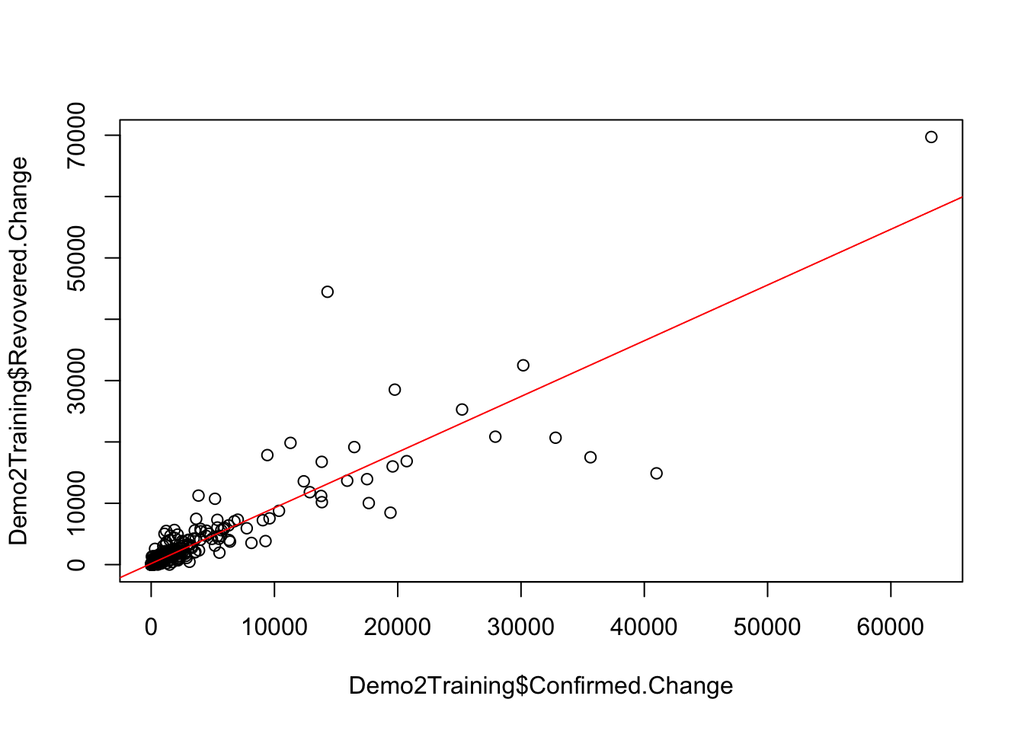

```r
plot(Demo2Training$Confirmed.Change, Demo2Training$Revovered.Change)
abline(fitlm, col="red")
```

#### Checking MAE and MSE

```r
library(MLmetrics)
ypred <-predict(object = fitlm, newdata = Demo2Test[,3:8])
summary(ypred)
```

```
##    Min. 1st Qu.  Median    Mean 3rd Qu.    Max.
##   148.8   184.5   347.3  1804.3  1271.6 63506.9
```

```r
MAE(y_pred = ypred, y_true = Demo2Test$Confirmed.Change)
```

```
## [1] 2308.895
```

```r
MSE(y_pred = ypred, y_true = Demo2Test$Confirmed.Change)
```

```
## [1] 27965134
```